# Model based Imputation Methods

## Imputing multiple variables

To impute several variables at once, the formula in `rangerImpute()` and `regressionImp()` can be specified with more than one column name in the left hand side.

```r
imp_regression <- regressionImp(Dream + NonD ~ BodyWgt + Span, dataset)
```

```
#> There still missing values in variable Dream . Probably due to missing values in the regressors.
#> There still missing values in variable NonD . Probably due to missing values in the regressors.
```

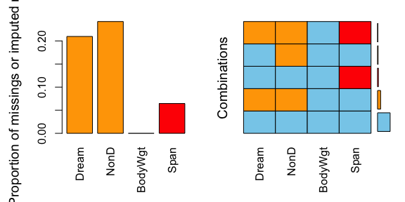

```r
imp_ranger <- rangerImpute(Dream + NonD ~ BodyWgt + Span, dataset)
aggr(imp_regression, delimiter = "_imp")
```

Again, there are missings left for both `Dream` and `NonD`.

## Performance of method

In order to validate the performance of `regressionImp()` the `iris` dataset is used. Firstly, some values are randomly set to `NA`.

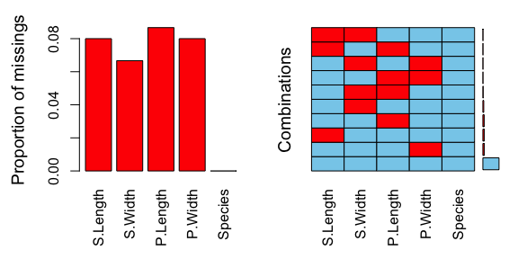

```r
library(reactable)

data(iris)
df <- iris
colnames(df) <- c("S.Length","S.Width","P.Length","P.Width","Species")
# randomly produce some missing values in the data
set.seed(1)
nbr_missing <- 50
y <- data.frame(row=sample(nrow(iris),size = nbr_missing,replace = T),
                col=sample(ncol(iris)-1,size = nbr_missing,replace = T))
y<-y[!duplicated(y),]
df[as.matrix(y)]<-NA

aggr(df)
```

```r
sapply(df, function(x)sum(is.na(x)))
```

```
#> S.Length  S.Width P.Length  P.Width  Species
#>       12       10       13       12        0
```

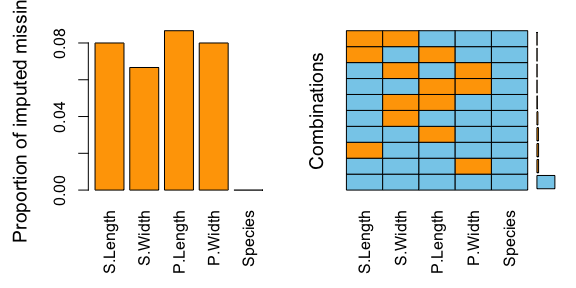

```r
imp_regression <- regressionImp(S.Length + S.Width + P.Length + P.Width ~ Species, df)
aggr(imp_regression, delimiter = "imp")
```

The plot indicates that all missing values have been imputed by the `regressionImp()` algorithm. The following table displays the rounded first five results of the imputation for all variables.

| True | Imputed | True | Imputed | True | Imputed | True | Imputed |
| --- | --- | --- | --- | --- | --- | --- | --- |
| 4.4 | 5.02 | 2.5 | 2.78 | 4.1 | 4.26 | 0.1 | 0.25 |
| 7 | 5.92 | 3 | 2.98 | 5.6 | 5.57 | 1.5 | 1.31 |
| 5.4 | 5.02 | 3 | 2.98 | 1.4 | 1.47 | 2.1 | 2.02 |
| 6.1 | 5.92 | 3.2 | 2.98 | 1.3 | 1.47 | 1.5 | 1.31 |
| 6.5 | 6.56 | 3.4 | 3.45 | 5.1 | 5.57 | 0.2 | 0.25 |